# Roulette Game Analysis: Exploring Patterns and Probabilities

## Introduction

This analysis explores 100,000 rounds of roulette data to uncover patterns, probabilities, and potential betting strategies. Using Python data science libraries, we'll analyze various aspects of roulette outcomes and betting patterns.

## Dataset Overview

The dataset contains:

- 100,000 rounds of roulette
- Winning numbers and colors
- Various bet outcomes (Red, Black, Even, Odd, Zero)

```python
# Necessary libraries
import pandas as pd
import numpy as np
import matplotlib.pyplot as plt
import seaborn as sns

# Display options
plt.style.use('default')  # Using default style instead of seaborn
pd.set_option('display.max_columns', None)

# Load the dataset
df = pd.read_csv('roulette_100000_rounds.csv')

# Display first few rows
print("First few rows of the dataset:")
print(df.head())
print("\nDataset Information:")
print(df.info())
```

```
First few rows of the dataset:
   Round  Winning Number Winning Color  Red Bet Win  Black Bet Win  \
0      1              22         Black            0              1
1      2               8         Black            0              1
2      3              33         Black            0              1
3      4               2         Black            0              1
4      5              24         Black            0              1

   Even Bet Win  Odd Bet Win  Zero Bet Win
0             1            0             0
1             1            0             0
2             0            1             0
3             1            0             0
4             1            0             0

Dataset Information:
<class 'pandas.core.frame.DataFrame'>
RangeIndex: 100000 entries, 0 to 99999
Data columns (total 8 columns):
 #   Column          Non-Null Count   Dtype
---  ------          --------------   -----
 0   Round           100000 non-null  int64
 1   Winning Number  100000 non-null  int64
 2   Winning Color   100000 non-null  object
 3   Red Bet Win     100000 non-null  int64
 4   Black Bet Win   100000 non-null  int64
 5   Even Bet Win    100000 non-null  int64
 6   Odd Bet Win     100000 non-null  int64
 7   Zero Bet Win    100000 non-null  int64
dtypes: int64(7), object(1)
memory usage: 6.1+ MB
None
```

## Research Questions

1. How do the actual probabilities of winning colors compare to theoretical probabilities in roulette?
2. What are the longest winning streaks for different bet types (Red, Black, Even, Odd)?
3. How would a player's bankroll be affected by different betting strategies?
4. Is there any noticeable bias in the distribution of winning numbers?
5. What is the frequency of alternation between Red and Black outcomes?
6. How do different betting systems perform over extended periods?

```
=== Question 1: Color Probability Analysis ===
```

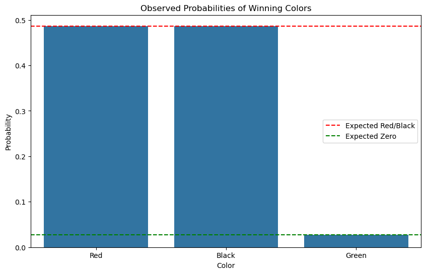

```python
print("\n=== Question 1: Color Probability Analysis ===")
color_counts = df['Winning Color'].value_counts()
total_spins = len(df)
color_probabilities = color_counts / total_spins

plt.figure(figsize=(10, 6))
sns.barplot(x=color_probabilities.index, y=color_probabilities.values)
plt.title('Observed Probabilities of Winning Colors')
plt.xlabel('Color')
plt.ylabel('Probability')
plt.axhline(y=18/37, color='r', linestyle='--', label='Expected Red/Black')
plt.axhline(y=1/37, color='g', linestyle='--', label='Expected Zero')
plt.legend()
plt.show()
```

```
=== Question 2: Streak Analysis ===
```

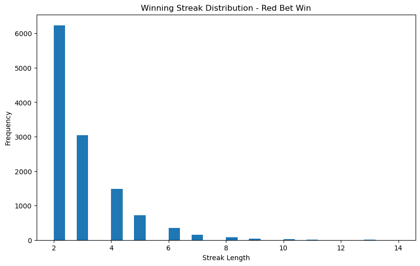

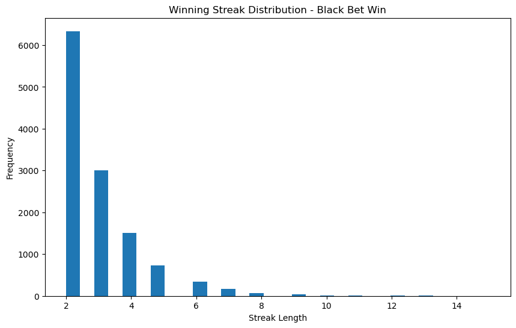

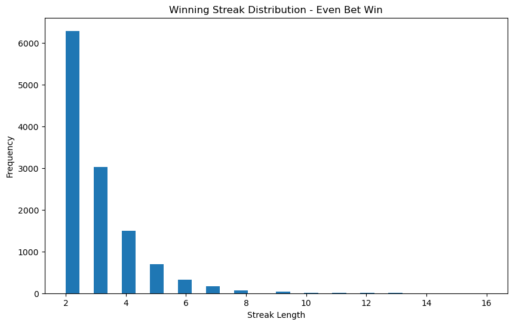

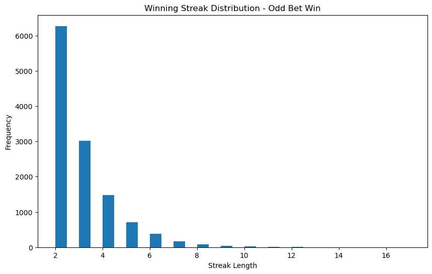

```python
print("\n=== Question 2: Streak Analysis ===")
def analyze_streaks(data, column):
    streak_count = 1
    streaks = []

    for i in range(1, len(data)):
        if data[column].iloc[i] == data[column].iloc[i-1] == 1:
            streak_count += 1
        else:
            if streak_count > 1:
                streaks.append(streak_count)
            streak_count = 1

    return streaks

bet_types = ['Red Bet Win', 'Black Bet Win', 'Even Bet Win', 'Odd Bet Win']
for bet_type in bet_types:
    streaks = analyze_streaks(df, bet_type)
    plt.figure(figsize=(10, 6))
    plt.hist(streaks, bins=30)
    plt.title(f'Winning Streak Distribution - {bet_type}')
    plt.xlabel('Streak Length')
    plt.ylabel('Frequency')
    plt.show()
```

```
=== Question 3: Bankroll Analysis ===
```

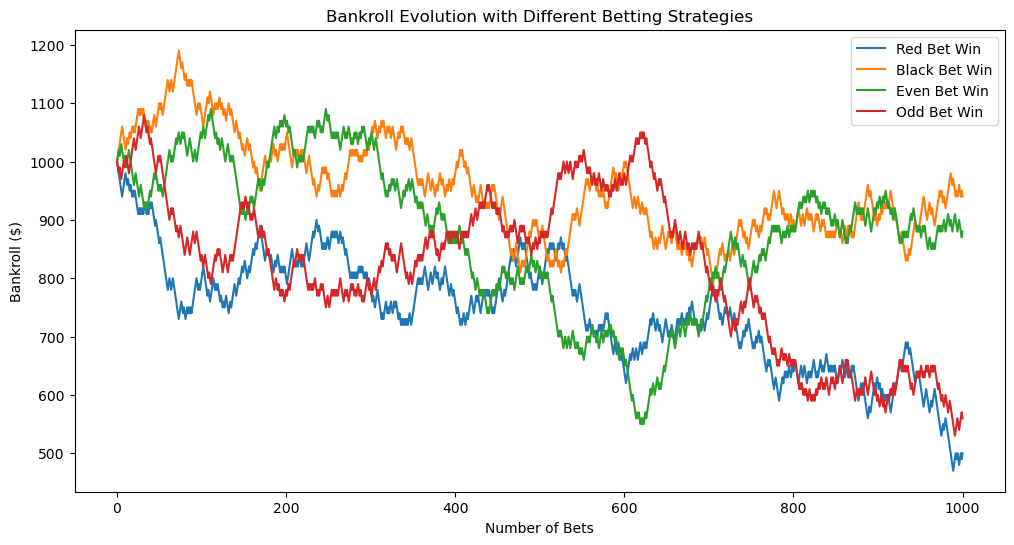

```python
print("\n=== Question 3: Bankroll Analysis ===")
def simulate_bankroll(data, initial_amount=1000, bet_amount=10, strategy='Red Bet Win'):
    bankroll = [initial_amount]
    current = initial_amount

    for i in range(len(data)):
        if data[strategy].iloc[i] == 1:
            current += bet_amount
        else:
            current -= bet_amount
        bankroll.append(current)

    return bankroll

strategies = ['Red Bet Win', 'Black Bet Win', 'Even Bet Win', 'Odd Bet Win']
plt.figure(figsize=(12, 6))
for strategy in strategies:
    results = simulate_bankroll(df.head(1000), strategy=strategy)
    plt.plot(results, label=strategy)

plt.title('Bankroll Evolution with Different Betting Strategies')
plt.xlabel('Number of Bets')
plt.ylabel('Bankroll ($)')
plt.legend()
plt.show()
```

```
=== Question 4: Number Distribution Analysis ===
```

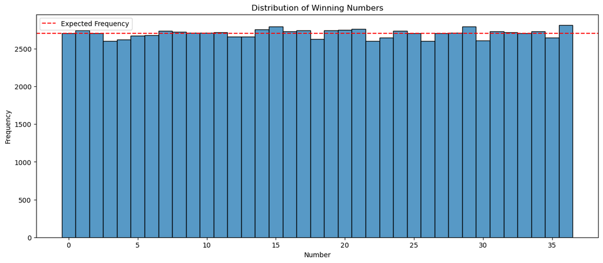

```python
print("\n=== Question 4: Number Distribution Analysis ===")
plt.figure(figsize=(15, 6))
sns.histplot(data=df, x='Winning Number', discrete=True)
plt.title('Distribution of Winning Numbers')
plt.xlabel('Number')
plt.ylabel('Frequency')
plt.axhline(y=len(df)/37, color='r', linestyle='--', label='Expected Frequency')
plt.legend()
plt.show()
```

```
=== Question 5: Color Alternation Analysis ===
```

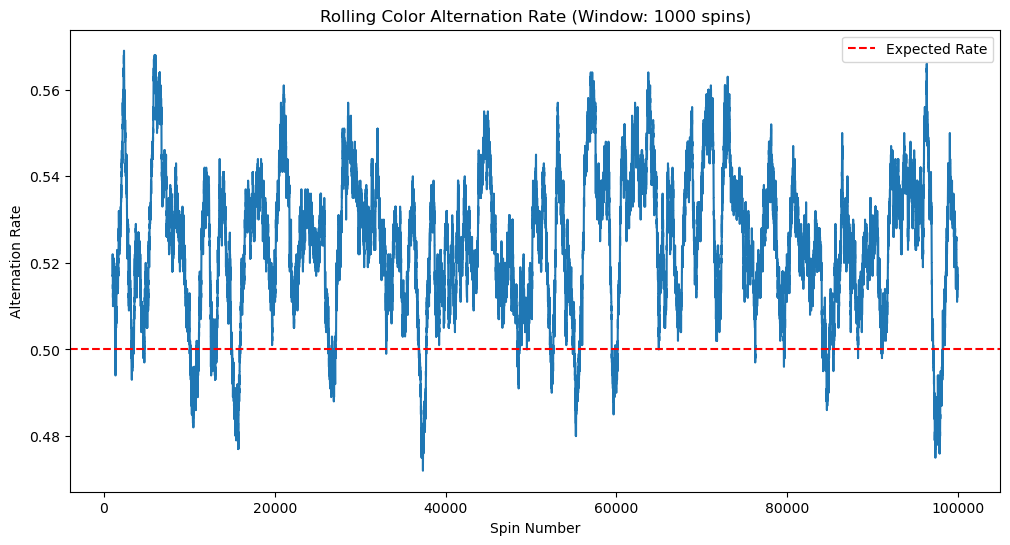

```python
print("\n=== Question 5: Color Alternation Analysis ===")
color_changes = (df['Winning Color'] != df['Winning Color'].shift()).sum()
alternation_rate = color_changes / (len(df) - 1)

window = 1000
rolling_alternation = (df['Winning Color'] != df['Winning Color'].shift()).rolling(window).mean()

plt.figure(figsize=(12, 6))
plt.plot(rolling_alternation)
plt.axhline(y=0.5, color='r', linestyle='--', label='Expected Rate')
plt.title(f'Rolling Color Alternation Rate (Window: {window} spins)')
plt.xlabel('Spin Number')
plt.ylabel('Alternation Rate')
plt.legend()
plt.show()
```

```
=== Question 6: Betting System Analysis ===
```

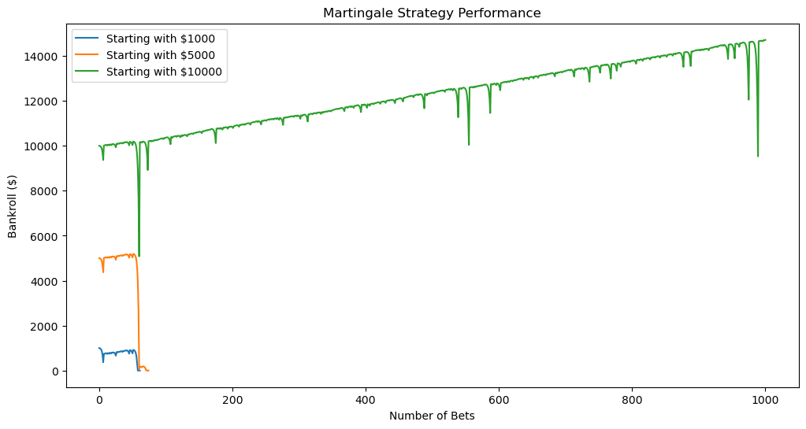

```python
print("\n=== Question 6: Betting System Analysis ===")
def martingale_strategy(data, initial_bankroll=1000, base_bet=10):
    bankroll = [initial_bankroll]
    current_bankroll = initial_bankroll
    current_bet = base_bet

    for i in range(len(data)):
        if current_bankroll < current_bet:
            break

        if data['Red Bet Win'].iloc[i] == 1:
            current_bankroll += current_bet
            current_bet = base_bet
        else:
            current_bankroll -= current_bet
            current_bet = min(current_bet * 2, current_bankroll)

        bankroll.append(current_bankroll)

    return bankroll

# Test different initial bankrolls
initial_amounts = [1000, 5000, 10000]
plt.figure(figsize=(12, 6))
for amount in initial_amounts:
    results = martingale_strategy(df.head(1000), initial_bankroll=amount)
    plt.plot(results, label=f'Starting with ${amount}')

plt.title('Martingale Strategy Performance')
plt.xlabel('Number of Bets')
plt.ylabel('Bankroll ($)')
plt.legend()
plt.show()
```